# Face Matching

## Problem statement:

**'Searching Faces in Wild'.**  
The problem we are trying to solve here is that a user gives an image or set of images of people not seen/known in advance and the task is to search these images across a given video feed.

**Complexity:**  
Unlike the problem of **face recognition** where there is an assumption of an already existing database of people on which a model can be trained(a **Supervised Learning** approach), the problem here is a bit hard because the analysis is done on completely unknown set of people; there are not sufficient number of images per person to train a model per say(an **Unsupervised Learning** approach).

## Imports

```python
from IPython.display import Image
from IPython.core.display import HTML
from face_matching_in_wild import FaceMatchingInWild
```

## Experiments and results

Different lines on which experiments have been carried out**:

- Single person matching, then extension to multiple people
- Using static images, then extending the same for video streams
- Simple **hog** based approach, then moving on to more complex **CNN** based approach for finding and encoding faces. This move accounts for a boost in the accuracy.

**cases above also cover indoor and outdoor lighting conditions.

### Using HOG

HOG features for finding facial keypoints.

#### NOTE: the code below is to show landmarks for explanation purpose on how the algorithm works internally. It has not been exposed in the API.

## HOG facial feature detection

```
A face is located at pixel location Top: 224, Left: 172, Bottom: 508, Right: 452
```

[output not shown]

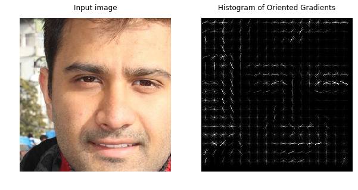

```python
import face_recognition
import cv2
import matplotlib.pyplot as plt
%matplotlib inline

import matplotlib.pyplot as plt
from skimage.feature import hog
from skimage import data, exposure
from scipy import misc
import numpy as np
from skimage import feature
from skimage import io

frame = cv2.imread('/home/anuj/Desktop/office-work/face-matching/Photos/Abhijay/Abhijay_0002.jpg')
small_frame = cv2.resize(frame, (0, 0), fx=0.25, fy=0.25)
rgb_small_frame = small_frame[:, :, ::-1]

face_locations = face_recognition.face_locations(rgb_small_frame, number_of_times_to_upsample=2, model="cnn")

# Print the location of each face in this image
(top, right, bottom, left) = face_locations[0]
top *= 4
right *= 4
bottom *= 4
left *= 4

print("A face is located at pixel location Top: {}, Left: {}, Bottom: {}, Right: {}".format(top, left, bottom, right))

# You can access the actual face itself like this:
face_image = frame[top:bottom, left:right]
# plt.axis('off')
# plt.imshow(face_image);

gray_image = cv2.cvtColor(face_image, cv2.COLOR_BGR2GRAY)
fd, hog_image = hog(gray_image, orientations=8, pixels_per_cell=(16, 16),
                cells_per_block=(1, 1), visualise=True)

fig, (ax1, ax2) = plt.subplots(1, 2, figsize=(10, 5), sharex=True, sharey=True)

ax1.axis('off')
ax1.imshow(np.flip(face_image, axis=2), cmap=plt.cm.gray)
ax1.set_title('Input image')
ax1.set_adjustable('box-forced')

# Rescale histogram for better display
hog_image_rescaled = exposure.rescale_intensity(hog_image, in_range=(0, 10))

ax2.axis('off')
ax2.imshow(hog_image_rescaled, cmap=plt.cm.gray)
ax2.set_title('Histogram of Oriented Gradients')
ax1.set_adjustable('box-forced')
plt.show()
```

### Detections using HOG features

- It can be seen below that detections using HOG features is decent but it misses the faces which are non-frontal.
- The only advantage of using this method is it doesn't consumes much resources in terms of RAM and GPU.

```python
Image(url= "hog_output.jpg")
```

[figure not shown]

### Using CNN

- Face detection runs the best using CNN.
- Using CNN with below mentioned configurable parameters helps in detecting people with NON-FRONTAL faces as well hence it would be much useful in actual scenarios.
- We detect what is called as 'facial landmarks' on given images, these landmarks are then endcoded in a 128 dimensional, non-linear vector which has a lot more specific information about an individual face.
- For a given test image also we compute the same feature vector and make a non-linear comparison. This is how we find faces in wild.

**Configurable parameters:**

1. number of times to upsample
2. number of jitters

**model is a ResNet network with 29 conv layers. It's essentially a version of the ResNet-34 network from the paper Deep Residual Learning for Image Recognition by He, Zhang, Ren, and Sun with a few layers removed and the number of filters per layer reduced by half.

#### NOTE: the code below is to show landmarks for explanation purpose on how the algorithm works internally. It has not been exposed in the API.

## Landmark detection using CNN

[figure not shown]

```python
import random
import numpy as np
import matplotlib.pyplot as plt
import cv2
import face_recognition

def show_landmarks(image_file, blank_image):
    """
    image_file: numpy array
    output:landmark on the image
    """
    face_landmarks_list = face_recognition.face_landmarks(image_file)
    for landmarks in face_landmarks_list:
        for landmark_name, landmark_location in landmarks.items():
            color = (0, 255, 0)
            landmark_location = map(list,landmark_location)
            landmark_location = np.array(landmark_location)
            cv2.polylines(blank_image,[landmark_location],0,color, 2)

#         blank_image = np.flip(blank_image,axis=2)
    return blank_image


input_image_1 = cv2.imread('Abhijay_0002.jpg')
blank_image = np.zeros((input_image_1.shape[0],input_image_1.shape[1],3), np.uint8)
output_image_1 = show_landmarks(input_image_1, blank_image)


# input_image_2 = cv2.imread('Nikhil_0016.jpg')
# output_image_2 = show_landmarks(input_image_2)

fig, (ax1, ax2) = plt.subplots(1, 2, figsize=(16, 10))

ax1.axis('off')
ax1.imshow(np.flip((input_image_1), axis = 2))

ax2.axis('off')
ax2.imshow(output_image_1)

plt.show()
```

### Output of detections using CNN

- It can be seen below that detections using resnet based landmark detection is very accurate in terms of detections.
- It requires GPU back-end.

```python
Image(url= "cnn_output.jpg")
```

[figure not shown]

## API functions

- Every face is in the incoming frame from video is compared in real-time with features of the input image.

### 1. Video object instantiation

**function:** FaceMatchingInWild()

- **input param:** path to video

```python
video_object = FaceMatchingInWild('/home/anuj/Desktop/office-work/face-matching/outside_office_faces.avi')
```

```
***Initialization Complete!***
```

### 2. Load test images

**function:** load_unknown_faces()

```python
video_object.load_unknown_faces()
```

```
loading image: Abhijay_0002.jpg
loading image: Anuj_0001.jpg
```

### 3. Run Face Matching Algorithm

**function:** run_face_matching()

```python
video_object.run_face_matching()
```

```
frame no: 0

Found 5 faces in the frame
frame no: 1

Found 5 faces in the frame
frame no: 2

Found 5 faces in the frame
frame no: 3

Found 5 faces in the frame
frame no: 4

Found 5 faces in the frame
frame no: 5

Found 5 faces in the frame
frame no: 6

Found 5 faces in the frame
frame no: 7

Found 5 faces in the frame
frame no: 8

Found 5 faces in the frame
frame no: 9

Found 5 faces in the frame
frame no: 10

Found 5 faces in the frame
frame no: 11

Found 5 faces in the frame
frame no: 12

Found 5 faces in the frame
frame no: 13
```

[output cut: 108 more lines]

```

Found 5 faces in the frame
frame no: 50

Found 5 faces in the frame
frame no: 51

Found 5 faces in the frame
frame no: 52

Found 5 faces in the frame
frame no: 53

Found 5 faces in the frame
output video location: /home/anuj/git/work/github/video-analytics/video-analytics-api/city/bangalore/face_matching/output/bangalore/face_matching/outside_office_faces/2018_01_17_18_36_04_face_match_output.avi
```

### Sample Output - image

```python
Image(url= "sample_output.jpg")
```

[figure not shown]

### Sample Output - video

```python
import IPython.display as Disp
Disp.IFrame('output.mp4', width=640, height=480)
```

[interactive chart not shown]

## Accuracy

Accuracy has been calculated while considering some base cases below.

### Case 1. Two people being searhed, one actually present in the frame other not present

People taken: gajanan, nikhil (when gajanan is present and nikhil is not in the video)

**Total frames** = 200

**Miss count** = 2

**False count** = 7

```python
total_frames = 200
miss_count = 2.0
false_count = 7.0
accuracy = ((total_frames - (miss_count+false_count))/total_frames)*100
```

```python
print("Accuracy over {} frames is: {}%".format(total_frames, accuracy))
```

```
Accuracy over 200 frames is: 95.5%
```

### Case 2. Person being searched is not present in the entire video

People taken: Aaron_Eckhart (when he is not present in the video)

**Total frames** = 200

```python
total_frames = 200
false_count = 21.0
accuracy = ((total_frames - (false_count))/total_frames)*100
```

```python
print("Accuracy over {} frames is: {}%".format(total_frames, accuracy))
```

```
Accuracy over 200 frames is: 89.5%
```